# Clasificación supervisada con el dataset mtcars

## 7. Boxplots Comparativos

Mostrar la distribución de mpg por número de cilindros usando geom_boxplot().

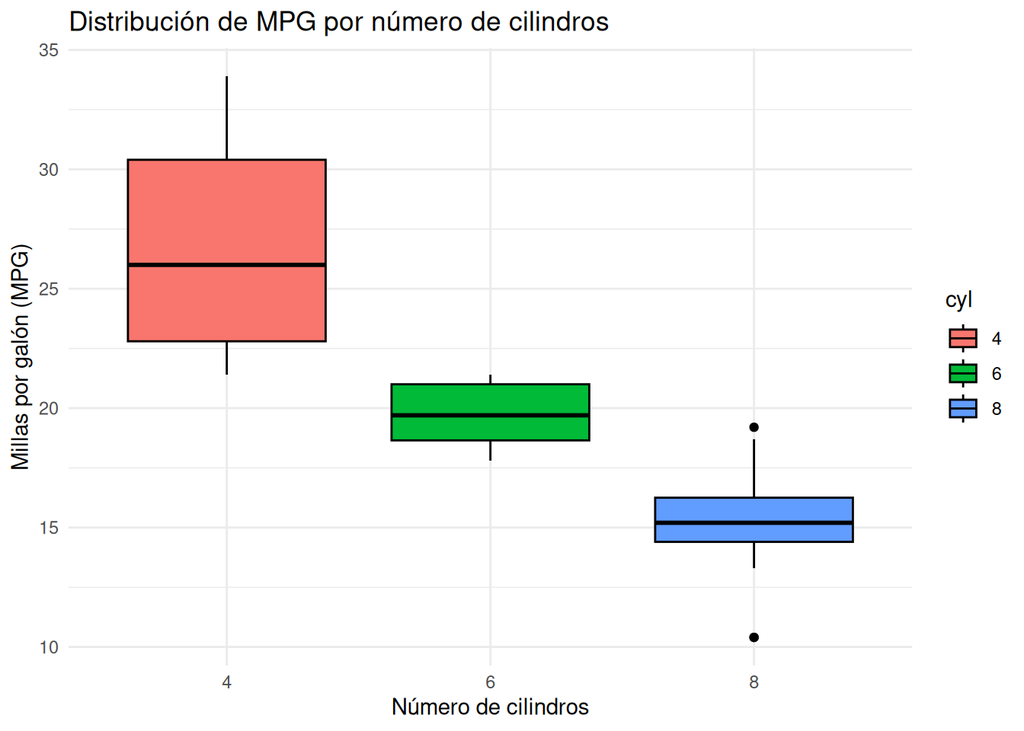

```r
ggplot(mtcars, aes(x = cyl, y = mpg, fill = cyl)) +
  geom_boxplot(col = "black") +
  labs(title = "Distribución de MPG por número de cilindros",
       x = "Número de cilindros",
       y = "Millas por galón (MPG)") +
  theme_minimal()
```

## 8. Conclusión

Los autos con 4 cilindros son más eficientes en consumo de combustible (mayor mpg) que los de 6 y 8 cilindros, pero tiene más variación que sus homólogos.

### Resultados clave de la regresión:

Intercepto: 37.2851 Esto representa el valor estimado de mpg cuando el peso (wt) es cero (aunque no tiene interpretación práctica directa).

Coeficiente de wt: −5.3445 Por cada unidad adicional de peso (en miles de libras), se espera que el consumo (mpg) disminuya en aproximadamente 5.34 millas por galón.

R² (R cuadrado): 0.7528 Esto indica que el modelo explica aproximadamente el 75.3% de la variabilidad en el consumo de combustible.

## Extra 1. Modelo de regresión

Regresión lineal simple entre mpg y wt.

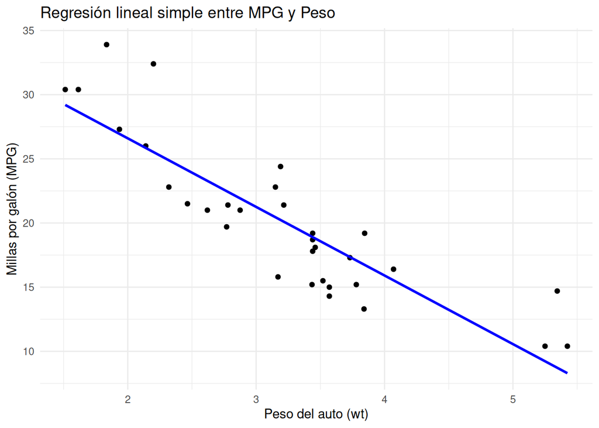

```r
modelo_simple <- lm(mpg ~ wt, data = mtcars)
ggplot(modelo_simple, aes(x = wt, y = mpg)) +
  geom_point() +
  geom_smooth(method = "lm", formula = (y ~ x),se = FALSE, color = "blue") +
  labs(title = "Regresión lineal simple entre MPG y Peso",
       x = "Peso del auto (wt)",
       y = "Millas por galón (MPG)") +
  theme_minimal()
```